# Computer Test

STAT5003 Semester 2, 2021

2021

### Question 1

Consider the number of Covid cases in both NSW and VIC since NSW (Greater Sydney) entered the lockdown due to the Delta variant starting on 26th June 2021. The full data is available on github and can be shared after the assessment. The goal of this question is to compare the growth in the number of cases between NSW and VIC since their most recent lockdown restrictions began. For NSW that was 26th June 2021. For VIC, assume this date to be 5th August 2021. The relevant data for this question has been saved into a `rds` file that contains case counts for NSW and VIC respectively. The data can be loaded with the following command.

```r
vic.delta.wave <- readRDS("S2-2021-Q1-vic-delta-wave.rds")
nsw.delta.wave <- readRDS("S2-2021-Q1-nsw-delta-wave.rds")
```

Using this data, answer the following questions.

1. [**3 marks**] Determine the structure and dimension of the `vic.delta.wave` and `nsw.delta.wave`.

   ```r
   # Input your answer here
   ```

   **Solution**:

   ```r
   str(vic.delta.wave)
   ```

   ```
   ## 'data.frame':    88 obs. of  2 variables:
   ##  $ date     : Date, format: "2021-06-26" "2021-06-27" "2021-06-28" "2021-06-29" ...
   ##  $ confirmed: int  3 3 0 2 2 -1 2 0 1 2 ...
   ```

   ```r
   str(nsw.delta.wave)
   ```

   ```
   ## 'data.frame':    88 obs. of  2 variables:
   ##  $ date     : Date, format: "2021-06-26" "2021-06-27" "2021-06-28" "2021-06-29" ...
   ##  $ confirmed: int  12 32 22 20 28 28 32 40 16 37 ...
   ```

2. [**3 marks**] Using `R` code and the data provided, determine the number of days each state has been in their most recent lockdown. To do this, remove the days from the VIC dataset that occurred **before** 5th August 2021. Note marks will be awarded for both the correct number of days for each state and for a correct R code statement to generate that value. **Hint**: The `subset` or an equivalent command is useful here. The `date` columns have the `Date` data type and date comparisons can be made by converting a string to a `Date` with `as.Date`. E.g. `date > as.Date("2020-12-31")` will return `TRUE` for any values in `date` after 31st December 2020 and `FALSE` otherwise.

   ```r
   # Input your answer here
   ```

   **Solution**:

   ```r
   nsw.days <- nrow(nsw.delta.wave)
   vic.delta.wave <- subset(vic.delta.wave, date >= as.Date("2021-08-05"))
   vic.days <- sum(with(vic.delta.wave, date >= as.Date("2021-08-05")))
   days <- setNames(c(nsw.days, vic.days), c("NSW", "VIC"))
   days
   ```

   ```
   ## NSW VIC
   ##  88  48
   ```

3. [**2 marks**] Add two new columns to each dataset.
   - `days.in.lockdown`: a simple integer counting the number of days the state started the latest lockdown (the first day of lockdown will count as zero here, e.g. `days.in.lockdown` should be zero for NSW and VIC on 26th June and 5th August respectively).
   - `state`: A simple label for each of the two data.frames with the repeated character of `"NSW"` or `"VIC"` for the New South Wales and Victoria datasets respectively.

   ```r
   # Input your answer here
   ```

   **Solution**:

   ```r
   nsw.delta.wave <- transform(nsw.delta.wave,
                               days.in.lockdown = as.numeric(date - as.Date("2021-06-26")),
                               state = "NSW")
   vic.delta.wave <- transform(vic.delta.wave, state = "VIC")
   vic.delta.wave <- transform(vic.delta.wave, days.in.lockdown = as.numeric(date - as.Date("2021-08-05")))
   ```

4. [**1 mark**] Merge the two datasets into a combined `data.frame`, joining by **row** (Hint: `rbind` is useful for this purpose).

   ```r
   # Input your answer here
   ```

   **Solution**:

   ```r
   delta.wave <- rbind(nsw.delta.wave, vic.delta.wave)
   ```

5. [**8 marks**] Using your merged data set above or otherwise, create a **scatterplot** showing the number of covid cases experienced by the two states. In your answer
   - show the number of cases on the y-axis
   - show the days in the latest lockdown on the x-axis (not the Date Variable)
   - add a separate nonparametric smoother for each of the NSW and VIC.
   - use appropriate informative labels and a legend
   - using your plot, comment on whether the delta outbreak is growing faster or slower in VIC compared to NSW.

   ```r
   # Input your answer here
   ```

   **Solution**:

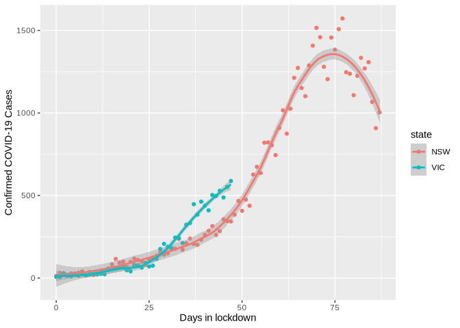

   ```r
   delta.wave <- rbind(nsw.delta.wave, vic.delta.wave)
   library(ggplot2)
   base.plot <- ggplot(delta.wave, aes(x = days.in.lockdown, y = confirmed, colour = state)) +
       labs(x = "Days in lockdown", y = "Confirmed COVID-19 Cases")
   base.plot + geom_point() + geom_smooth(formula = y ~ x, method = 'loess', span = 0.5)
   ```

From the plot we can see that VIC appears to be growing faster than NSW after the 25th day in lockdown due to the steeper slope in the curve. NSW has a sharp increase in slope shortly after but VIC hasnt reached this point in time yet.

### Question 2

For this question, the same data as Question 1 is used but focuses on the NSW case numbers from day 50 to 75 of their lockdown. This data is provided in the RDS file below. A colleague mentions that this data looks linear over this time periods and wants to statistically examine a model.

```r
q2.dat <- readRDS("S2-2021-Q2.rds")
```

1. [**4 marks**] Compute a linear regression of the confirmed covid cases (outcome) against the days in lockdown (feature). In your answer
   - plot the data with a scatterplot and the least squares regression line.
   - Use informative axis labels
   - compute and print the standard error of the slope coefficient.

   ```r
   # Input your answer here
   ```

   **Solution**:

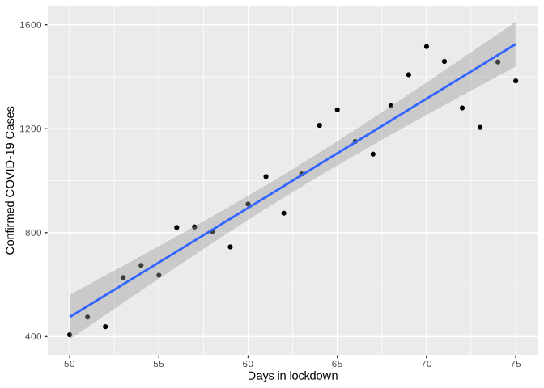

   ```r
   q2.basic.plot <- ggplot(q2.dat, aes(x = days.in.lockdown, y = confirmed))
   q2.basic.plot + geom_point() +
       geom_smooth(formula = y ~ x, method = "lm") +
       labs(x = "Days in lockdown", y = "Confirmed COVID-19 Cases")
   ```

   ```r
   lm.summary <- summary(lm(confirmed ~ days.in.lockdown, data = q2.dat))
   standard.error <- lm.summary[['coefficients']]['days.in.lockdown', 'Std. Error']
   standard.error
   ```

   ```
   ## [1] 2.857129
   ```

2. [**7 marks**] Write your **own** function in `R` that computes the bootstrapped estimate of the standard error of the slope coefficient of such a linear regression. Minimal marks will be awarded for a correct answer that uses an external package at this step. The answer should be written in `base` R code. In your answer,
   - Write a function called `simple_regression_from_data` that takes one argument, a `data.frame` with 2 columns with variables suitable for a linear regression. It computes a linear regression of the second column (outcome) against the first column (feature) and returns just the regression slope coefficient (not the intercept).
   - Compute bootstrap samples of the data. Use `B = 26` bootstrap resamples.
   - Compute the linear regression slope for each of the bootstrapped datasets.
   - Compute the standard error of your bootstrapped slopes.
   - Compare the bootstrapped standard error with the standard slope standard error.

   ```r
   # Input your answer here
   set.seed(5003)
   # simple_regression_from_data <- function
   ```

   **Solution**:

   ```r
   set.seed(5003)
   simple_regression_from_data <- function(dat) {
       lsfit(dat[[1L]], dat[[2L]])[["coefficients"]][2]
   }
   B <- 1:nrow(q2.dat)
   bootstrapped.data <- lapply(B, \(x) q2.dat[sample.int(nrow(q2.dat), replace = TRUE, size = nrow(q2.dat)), ])
   bootstraped.coefs <- vapply(bootstrapped.data, simple_regression_from_data, numeric(1L))
   slopes <- bootstraped.coefs
   bootstrapped.se <- c('Raw bootstrapped estimated sd' = sd(slopes))
   bootstrapped.se
   ```

   ```
   ## Raw bootstrapped estimated sd
   ##                      3.044267
   ```

   ```r
   c(diff = standard.error - bootstrapped.se)
   ```

   ```
   ## diff.Raw bootstrapped estimated sd
   ##                         -0.1871384
   ```

   The bootstrapped standard error is larger than the computed standard error.

### Question 3

```r
nps.data <- readxl::read_xlsx("NPS_DummyData.xlsx")
set.seed(5003)
nps.data <- na.omit(nps.data)
q3.dat <- nps.data[sample.int(nrow(nps.data), size = 1e3), ] |>
    subset(select = c("Overall Satisfaction", "Value", "Quality", "Expertise", "Communication")) |>
    transform(`Will recommend` = `Overall Satisfaction` >= 8)
q3.dat$Will.recommend <- with(q3.dat, factor(c("No", "Yes")[Will.recommend + 1]))
q3.dat <- q3.dat[, names(q3.dat) != "Overall.Satisfaction"]
saveRDS(q3.dat, file = "q3-dat.rds")
set.seed(5003)
fold <- caret::createDataPartition(q3.dat$Will.recommend, p = 0.75)[[1L]]
# For convenience, put the 5 fold CV sets into a list
which.group = factor(ifelse(seq(nrow(q3.dat)) %in% fold, "Training", "Test"))
dat <- split(q3.dat, which.group)
training.data <- dat$Training
lda.model <- MASS::lda(Will.recommend ~ ., data = dat$Training)
svm.model <- e1071::svm(Will.recommend ~ ., data = dat$Training)
saveRDS(lda.model, file = 'S2-2021-Q3-lda-model.rds')
saveRDS(svm.model, file = 'S2-2021-Q3-svm-model.rds')
test.dat <- dat$Test
saveRDS(test.dat, file = 'S2-2021-Q3-test-data.rds')
```

A market research study into a new product for a company was conducted. Classification models to determine if a client will recommend their product is required based off their assessment of the company product. The table below shows describes the variables

| Variable | Description | Variable type |
| --- | --- | --- |
| Will.recommend | Whether the customer will recommend the product (Yes) or not (No) | Outcome |
| Value | The score from 1 (terrible) to 10 (great) about the value the customer sees in the product | Feature |
| Quality | The score from 1 (terrible) to 10 (great) about the quality level of the product | Feature |
| Expertise | The score from 1 (terrible) to 10 (great) about the expertise level of customer support staff | Feature |
| Communication | The score from 1 (terrible) to 10 (great) about the communication level of the company | Feature |

Two classification models have been constructed, an LDA and an SVM. Using the fitted models `R` provided below. Determine which model performs better on the provided test data.

```r
lda.model <- readRDS('S2-2021-Q3-lda-model.rds')
svm.model <- readRDS('S2-2021-Q3-svm-model.rds')
test.data <- readRDS('S2-2021-Q3-test-data.rds')
```

1. [**4 marks**] Using the models, predict the labels on the test data. Then create (and print) a confusion matrix for each of the two models.

   ```r
   # Input your answer here
   ```

   **Solution**:

   ```r
   models <- list(lda.model, svm.model)
   cM <- lapply(models, \(x) {
       predicted <- predict(x, newdata = test.data, type = "response")
       if (is.list(predicted))
           predicted <- predicted[["class"]]
       caret::confusionMatrix(predicted, test.data$Will.recommend, positive = "Yes")
   })
   setNames(cM, c("LDA", "SVM"))
   ```

   ```
   ## $LDA
   ## Confusion Matrix and Statistics
   ##
   ##           Reference
   ## Prediction  No Yes
   ##        No   29   7
   ##        Yes  22 192
   ##
   ##                Accuracy : 0.884
   ##                  95% CI : (0.8377, 0.9209)
   ##     No Information Rate : 0.796
   ##     P-Value [Acc > NIR] : 0.0001718
   ##
   ##                   Kappa : 0.599
   ##
   ##  Mcnemar's Test P-Value : 0.0093296
   ##
   ##             Sensitivity : 0.9648
   ##             Specificity : 0.5686
   ##          Pos Pred Value : 0.8972
   ##          Neg Pred Value : 0.8056
   ##              Prevalence : 0.7960
   ##          Detection Rate : 0.7680
   ##    Detection Prevalence : 0.8560
   ##       Balanced Accuracy : 0.7667
   ##
   ##        'Positive' Class : Yes
   ##
   ##
   ## $SVM
   ## Confusion Matrix and Statistics
   ##
   ##           Reference
   ## Prediction  No Yes
   ##        No   40  12
   ##        Yes  11 187
   ##
   ##                Accuracy : 0.908
   ##                  95% CI : (0.8652, 0.9408)
   ##     No Information Rate : 0.796
   ##     P-Value [Acc > NIR] : 1.333e-06
   ##
   ##                   Kappa : 0.7188
   ##
   ##  Mcnemar's Test P-Value : 1
   ##
   ##             Sensitivity : 0.9397
   ##             Specificity : 0.7843
   ##          Pos Pred Value : 0.9444
   ##          Neg Pred Value : 0.7692
   ##              Prevalence : 0.7960
   ##          Detection Rate : 0.7480
   ##    Detection Prevalence : 0.7920
   ##       Balanced Accuracy : 0.8620
   ##
   ##        'Positive' Class : Yes
   ##
   ```

[**2 marks**]

1. Determine which is the better model on this set of test data using the confusion matrices or any other relevant classification metric discussed in the STAT5003 content.

   ```r
   # Input your answer here
   ```

   At a fundamental level (accuracy), SVM is superior to the LDA. The LDA has a higher sensitivity than the SVM but the balanced accuracy is higher in the SVM.

|  | Marks |
| --- | --- |
| Q1 | 17 |
| Q2 | 11 |
| Q3 | 6 |
| Total | 34 |